# Classifier results after end to end reprocessing

North Tyneside Led PD study (Walker). Sites: North Tyneside, Cumbria, Durham & Darlington, Sunderland and Gateshead.

Published

March 9, 2023

| Date | Change | Author |
| --- | --- | --- |
| 06/03/2023 | Document creation | David Bramwell |

## 1 Purpose of this document

This document brings together the end to end reprocessing of the available files listed in `Analytics/classifClasses_76patients_21HC.xlsx`.

These results are generated by the Snapshot code going end to end and reprocessing using the latest FE code (1.1.20). It then applies all of the classifiers.

Not all of the files could be processed and the results may differ from previous results.

The report was intended to test the end to end and the results need to be checked in more detail against other sources.

## 2 Classifier results

The snapshot processing results are collated by a test instance:

```python
def test_76patients21HC(self):
    # load data for classification - classes
    dfClasses = pd.read_excel(r'Analytics/classifClasses_76patients_21HC.xlsx')
    dfh = DataFileHelper()
    found_entries={}
    classed_entries={}
    for test_src_index in range(0,len(dfClasses[['file']])):
        test_src = dfClasses['file'][test_src_index]
        if test_src in dfh.JSON_file_lookup.keys():
            found_entries[test_src]=dfh.JSON_file_lookup[test_src]
            snapshot = SnapshotManagement(test_src,snapshot_tag=SnapshotManagement.CandidateSnapshot)
            if os.path.exists(snapshot.Features_classify_file()):
                with open(snapshot.Features_classify_file(), 'r', encoding='utf-8') as fp:
                    json_data = json.load(fp)

                classed_entries[test_src] = {'Patient': dfClasses['Patient'][test_src_index],
                'PD': dfClasses['PD class'][test_src_index]
                }

                for i in json_data:
                    if 'ClassifyVersion' in i.keys():
                        if i['ClassifyVersion'] in self.classifier_pairs:
                            res = {f"{self.classifier_pairs[i['ClassifyVersion']]}_class": "NA",
                                    f"{self.classifier_pairs[i['ClassifyVersion']]}_score": "NA"}
                            if "metrics" in i.keys():
                                res = {f"{self.classifier_pairs[i['ClassifyVersion']]}_class": i["metrics"]["classification"],
                                    f"{self.classifier_pairs[i['ClassifyVersion']]}_score": i["metrics"]["classification_score"]}
                            classed_entries[test_src].update(res)

        else:
            print(f"{test_src} not found")


    print(f"Matched {len(found_entries)}")
    print(f"Matched with class calculated {len(classed_entries)}")
    df = pd.DataFrame.from_dict(classed_entries).T
    df.to_csv('ClinicalMetadata/Walker_ParsedClassify.csv')
```

This produces the following collated results:

```r
    # csv file is generated by a test in test_classify.py
    walker_class = read.csv("Walker_ParsedClassify.csv")

    print(kable(walker_class,row.names=FALSE) %>% kable_styling())
```

| X | Patient | PD | HiSpec_class | HiSpec_score | RanFor_class | RanFor_score | BM_May22_class | BM_May22_score | BM_HC_Sep22_class | BM_HC_Sep22_score | BM_PD_Sep22_class | BM_PD_Sep22_score |
| --- | --- | --- | --- | --- | --- | --- | --- | --- | --- | --- | --- | --- |
| ManusData_010 2y fu.JSON | 1 | 1 | NOT PD | 0.78 | PD | 0.69 | NOT PD | 0.4235831 | Patient | 0.8698767 | PD | 0.5451176 |
| ManusData_018.JSON | 1 | 1 | NOT PD | 0.52 | NOT PD | 0.50 | PD | 0.8559859 | Patient | 0.9048918 | PD | 0.7259499 |
| ManusData_023.JSON | 1 | 1 | NOT PD | 0.73 | PD | 0.60 | PD | 0.3791823 | Healthy | 0.8387705 | PD | 0.7740070 |
| ManusData_028.JSON | 1 | 1 | NOT PD | 0.87 | PD | 0.56 | PD | 0.5373528 | Patient | 0.8695520 | PD | 0.6864638 |
| ManusData_034.JSON | 1 | 1 | NOT PD | 0.75 | PD | 0.64 | PD | 0.5630804 | Patient | 0.4214335 | PD | 0.6174221 |
| ManusData_039 v2.JSON | 1 | 1 | NOT PD | 0.90 | NOT PD | 0.61 | PD | 0.4442958 | Patient | 0.9202124 | nonPD | 0.4640046 |
| ManusData_040.JSON | 1 | 1 | NOT PD | 0.68 | PD | 0.52 | PD | 0.1982450 | Patient | 0.1149186 | PD | 0.6864638 |
| ManusData_043.JSON | 1 | 0 | NOT PD | 0.75 | PD | 0.51 | NOT PD | 0.6716878 | Patient | 0.6261545 | nonPD | 0.4781992 |
| ManusData_055.JSON | 1 | 1 | NOT PD | 0.78 | PD | 0.56 | PD | 0.8756432 | Patient | 0.9170884 | PD | 0.6672512 |
| ManusData_057.JSON | 1 | 1 | NOT PD | 0.74 | PD | 0.69 | PD | 0.6246394 | Patient | 0.8952060 | PD | 0.7901971 |
| ManusData_058.JSON | 1 | 0 | NOT PD | 0.70 | PD | 0.68 | NOT PD | 0.9133618 | Patient | 0.8947924 | nonPD | 0.4005964 |
| ManusData_061.JSON | 1 | 0 | NOT PD | 0.83 | PD | 0.61 | NOT PD | 0.8684229 | Patient | 0.8693955 | nonPD | 0.3072408 |
| ManusData_065.JSON | 1 | 0 | NOT PD | 0.74 | NOT PD | 0.51 | NOT PD | 0.9872118 | Patient | 0.9349326 | nonPD | 0.4640046 |
| ManusData_068.JSON | 1 | 0 | NOT PD | 0.74 | NOT PD | 0.58 | NOT PD | 0.5079458 | Patient | 0.9060959 | nonPD | 0.4651711 |
| ManusData_069.JSON | 1 | 1 | NOT PD | 0.84 | NOT PD | 0.53 | PD | 0.2059057 | Patient | 0.9283187 | nonPD | 0.4877727 |
| ManusData_074.JSON | 1 | 1 | NOT PD | 0.58 | PD | 0.73 | PD | 0.9918288 | Patient | 0.9147063 | PD | 0.7978056 |
| ManusData_079.JSON | 1 | 0 | NOT PD | 0.80 | PD | 0.61 | NOT PD | 0.4087719 | Patient | 0.8873380 | nonPD | 0.3072408 |
| ManusData_080.JSON | 1 | 1 | NOT PD | 0.74 | PD | 0.64 | PD | 0.5190591 | Patient | 0.9003500 | PD | 0.8477884 |
| ManusData_1.JSON | 1 | 1 | NOT PD | 0.70 | NA | NA | PD | 0.7309564 | Patient | 0.7025032 | PD | 0.6635103 |
| ManusData_pd_082_03112021011805.JSON | 1 | 1 | PD | 0.31 | NOT PD | 0.51 | PD | 0.6186071 | Healthy | 0.6656580 | PD | 0.6635103 |
| ManusData_pd_085_01032021021307.JSON | 1 | 1 | NOT PD | 0.66 | PD | 0.58 | NOT PD | 0.7090427 | Patient | 0.8693844 | PD | 0.7423821 |
| ManusData_pd_087_02032021030531.JSON | 1 | 1 | NOT PD | 0.74 | NOT PD | 0.55 | NOT PD | 0.5250705 | Patient | 0.8723916 | PD | 0.8720298 |
| ManusData_pd_091_23032021014020.JSON | 1 | 1 | NOT PD | 0.66 | PD | 0.56 | NOT PD | 0.6271159 | Patient | 0.9370724 | PD | 0.7423821 |
| ManusData_pd_093 3mnth fu_20072021021632.JSON | 1 | 1 | NOT PD | 0.64 | NOT PD | 0.59 | PD | 0.6248021 | Patient | 0.9364303 | nonPD | 0.4419235 |
| ManusData_pd_095_20042021023547.JSON | 1 | 1 | NOT PD | 0.63 | PD | 0.68 | NOT PD | 0.6185995 | Patient | 0.9037640 | PD | 0.6672512 |
| ManusData_pd_100bl_19052021031937.JSON | 1 | 1 | NOT PD | 0.57 | PD | 0.63 | NOT PD | 0.0486054 | Patient | 0.9278759 | PD | 0.7259499 |
| ManusData_pd_103_26052021042533.JSON | 1 | 1 | NOT PD | 0.86 | PD | 0.54 | NOT PD | 0.8806083 | Patient | 0.8992073 | PD | 0.6672512 |
| ManusData_pd_105_09062021035254.JSON | 1 | 1 | NOT PD | 0.74 | PD | 0.59 | PD | 0.8363957 | Patient | 0.9336671 | PD | 0.5451176 |
| ManusData_pd_106 bl_21062021023259.JSON | 1 | 0 | NOT PD | 0.91 | PD | 0.51 | NOT PD | 0.6183306 | Patient | 0.8693883 | nonPD | 0.2281569 |
| ManusData_pd_111 BL_14072021033339.JSON | 1 | 1 | NOT PD | 0.69 | NOT PD | 0.52 | PD | 0.2214665 | Patient | 0.9317958 | PD | 0.7137867 |

[output cut: 53 more lines]

Three internally generated files dropped out (‘HC_ManusData_pd_KRN1_09102020091136.JSON’, ‘ManusData_pd_newdevode_03062021041647.JSON’,‘ManusData_pd_ploppy_03062021091243.JSON’)

#### 2.0.1 Calibration and performance in the training set

Now we have the data collated and loaded we can use some relatively default functions to calculate performance and calibration on the recalcualted set.

We will be using [pROC](https://cran.r-project.org/web/packages/pROC/pROC.pdf) and [calibration_plot from predtools](https://resplab.github.io/predtools/articles/calibPlot.html) which calculates decile performance by default.

Now we create several simple plots and tabulated results.

### 2.1 Hi Spec

The first one simply plots the samples in ranked order against the probability values. The sample names are colour coded by diagnosis and upper or lower text is simply to avoid the plotted points. Ideally all the green are to the left and all the red to the right.

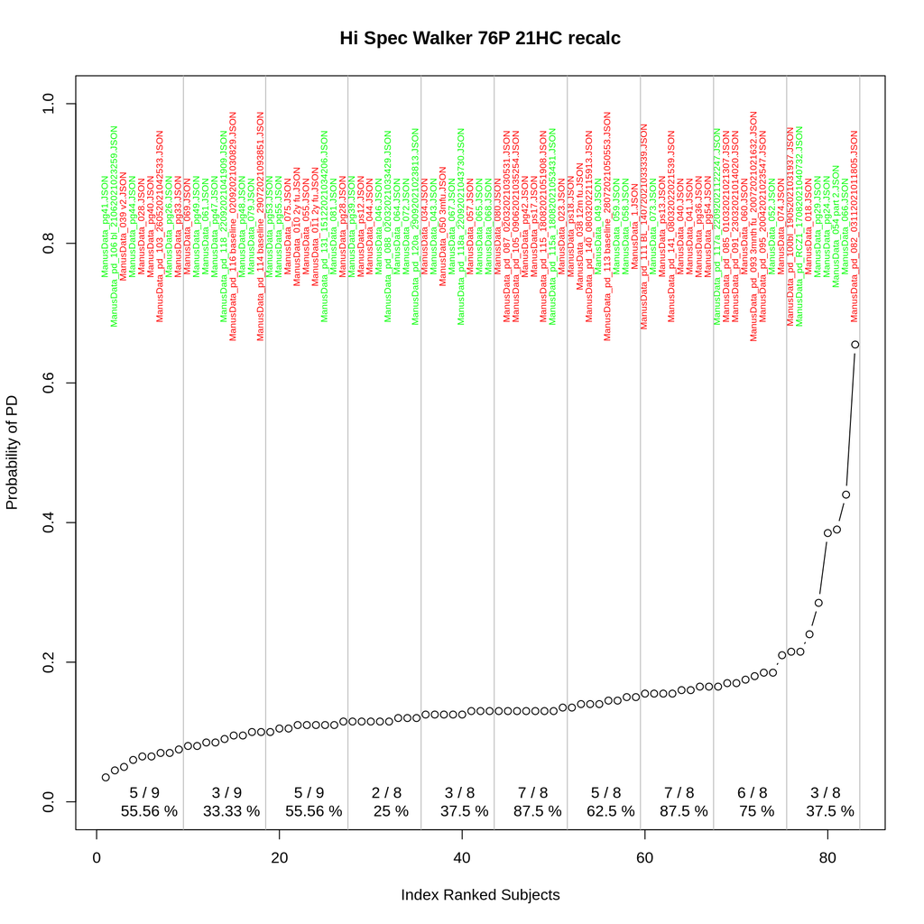

```r
  pred_detail <- DoClassifyPlots("Hi Spec","HiSpec")
```

Next a calibration plot (look at the page linked above for what they are supposed to look like).

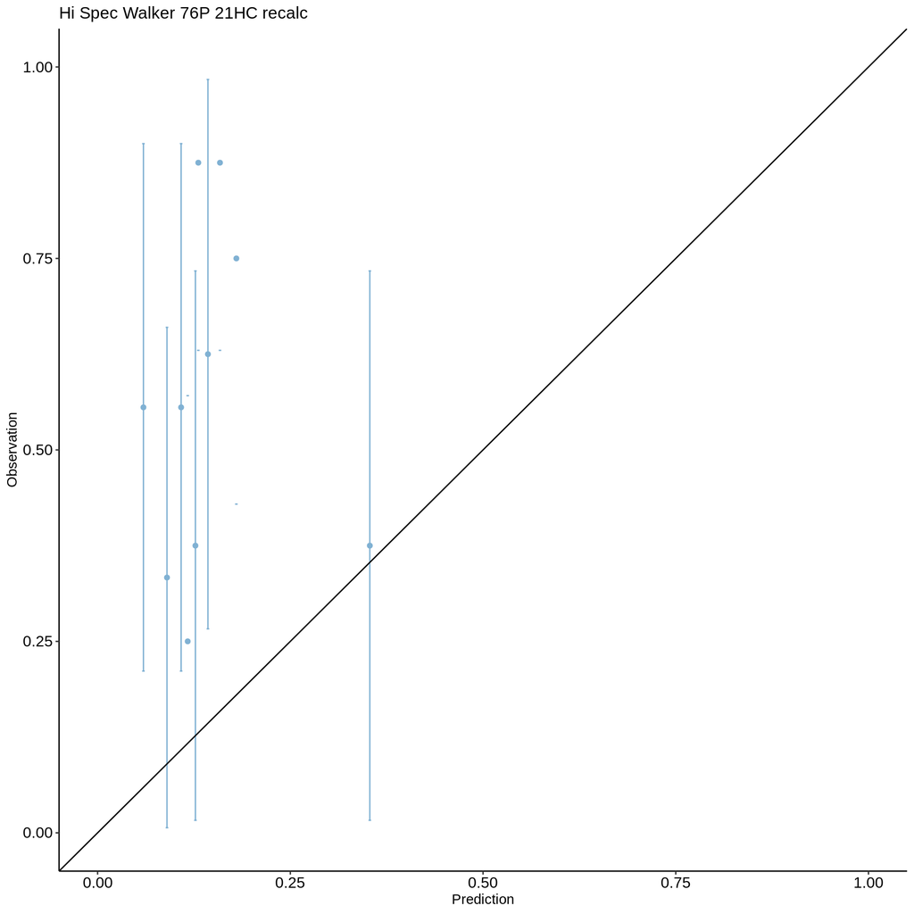

```r
  print(pred_detail$calib$calibration_plot)
```

Then the decile table returned by the ‘calibration_plot’ function.

```r
  print(kable(pred_detail$calib$data_summary,row.names=FALSE) %>% kable_styling())
```

| decile | obsRate | obsRate_SE | obsNo | predRate | obsRate_UCL | obsRate_LCL |
| --- | --- | --- | --- | --- | --- | --- |
| 1 | 0.5555556 | 0.1756821 | 9 | 0.0594444 | 0.8998925 | 0.2112187 |
| 2 | 0.3333333 | 0.1666667 | 9 | 0.0900000 | 0.6600000 | 0.0066667 |
| 3 | 0.5555556 | 0.1756821 | 9 | 0.1083333 | 0.8998925 | 0.2112187 |
| 4 | 0.2500000 | 0.1636634 | 8 | 0.1168750 | 0.5707803 | -0.0707803 |
| 5 | 0.3750000 | 0.1829813 | 8 | 0.1268750 | 0.7336433 | 0.0163567 |
| 6 | 0.8750000 | 0.1250000 | 8 | 0.1306250 | 1.1200000 | 0.6300000 |
| 7 | 0.6250000 | 0.1829813 | 8 | 0.1431250 | 0.9836433 | 0.2663567 |
| 8 | 0.8750000 | 0.1250000 | 8 | 0.1587500 | 1.1200000 | 0.6300000 |
| 9 | 0.7500000 | 0.1636634 | 8 | 0.1800000 | 1.0707803 | 0.4292197 |
| 10 | 0.3750000 | 0.1829813 | 8 | 0.3531250 | 0.7336433 | 0.0163567 |

Now a simple ROC curve with the details under it.

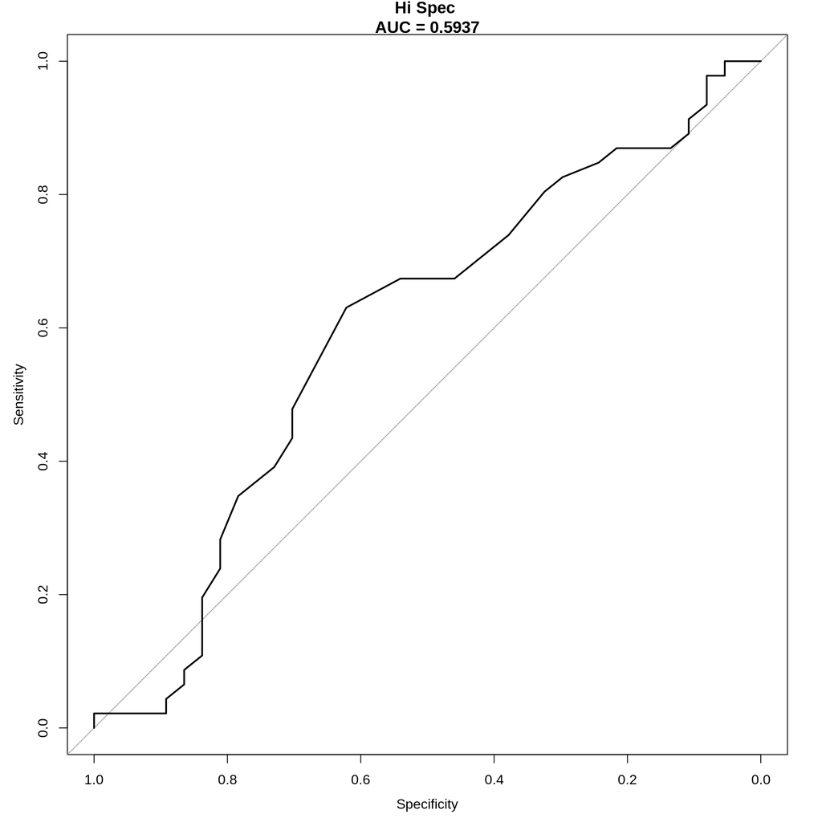

```r
  plot(pred_detail$roc,main=paste(pred_detail$desc,"\nAUC =",round(auc(pred_detail$roc),digits=4)))
```

```r
  print(pred_detail$roc)
```

```
Call:
roc.default(controls = retVal[!isControl, "probPD"], cases = retVal[isControl,     "probPD"], quiet = TRUE)

Data: 37 controls < 46 cases.
Area under the curve: 0.5937
```

We now list the sensitivities and specificities at each unique value for probability in the data.

```r
  print(kable(SensSpecTableFromROC(pred_detail$roc),col.names=c("threshold","sensitivities","specificities"),row.names=FALSE) %>% kable_styling())
```

| threshold | sensitivities | specificities |
| --- | --- | --- |
| 0.0475 | 100.00 | 5.41 |
| 0.0625 | 97.83 | 8.11 |
| 0.0725 | 91.30 | 10.81 |
| 0.0925 | 86.96 | 21.62 |
| 0.0975 | 84.78 | 24.32 |
| 0.1025 | 82.61 | 29.73 |
| 0.1075 | 80.43 | 32.43 |
| 0.1125 | 73.91 | 37.84 |
| 0.1225 | 67.39 | 54.05 |
| 0.1275 | 63.04 | 62.16 |
| 0.1325 | 47.83 | 70.27 |
| 0.1425 | 39.13 | 72.97 |
| 0.1475 | 36.96 | 75.68 |
| 0.1525 | 34.78 | 78.38 |
| 0.1575 | 28.26 | 81.08 |
| 0.1675 | 19.57 | 83.78 |
| 0.1975 | 8.70 | 86.49 |
| 0.2275 | 4.35 | 89.19 |
| 0.5475 | 2.17 | 100.00 |

### 2.2 Random Forest

**Important**

Initial backend commit is June 2021. This came from the original DiPar work but the current training file appears to include subjects from the Walker study so the test here is biased. I can’t find the original model files to load the model derived just from DiPar data(comment in code just says it should be in the same folder. It isn’t.)

The actual training files don’t have subject IDs against them so it is hard to be definitive. `dataset_details109.xlsx` does but the numbers don’t match `trainingData.csv`. `trainingData.csv` has 132 unlabelled FE data entries of 123 values. `trainingData.csv` comes from one of the first commits `Martin committed 25 Jun 2021 : #4 - Initial commit of the backend functions`

The Model.py code actually does a 70:30 train:test split on the data but then ignores the test. If you add the tests to it you get a ‘blind’ test accuracy of 0.8 and ROC AUC of 0.875 (as expected the train accuracy and ROC AUC are both perfect i.e. 1.0).

It is interesting that the most misranked ‘PD’ samples are both follow up visits where the patient is on treatment.

The most misranked ‘non PD’ is 072 (spouse). It has data alignment issues. All data plots as invalid in my reporting. Only 4 circle segments found. 8 Spiral segments. Data dropout issues in spiral. Beautiful handwriting in `elel`. `Zigzag_copy` and `Zigzag_trace` visually fine.

Next misranked ‘non PD’ is 058 (suspected PD). I cannot find a definitive diagnosis in the meta for him. No follow up listed or drug regimen and no DatScan. Raw data alignment issues. 8 circle segments. Visible data issues (strange flat spots on the bottom of the circles). Only 3 spirals segments, one with a data issue. Four `elel` segments with some issues (horizontal micrographia ?). Almost no `fitts_short` data. Four `Zigzag_trace` segments. Six `Zigzag_copy` segments.

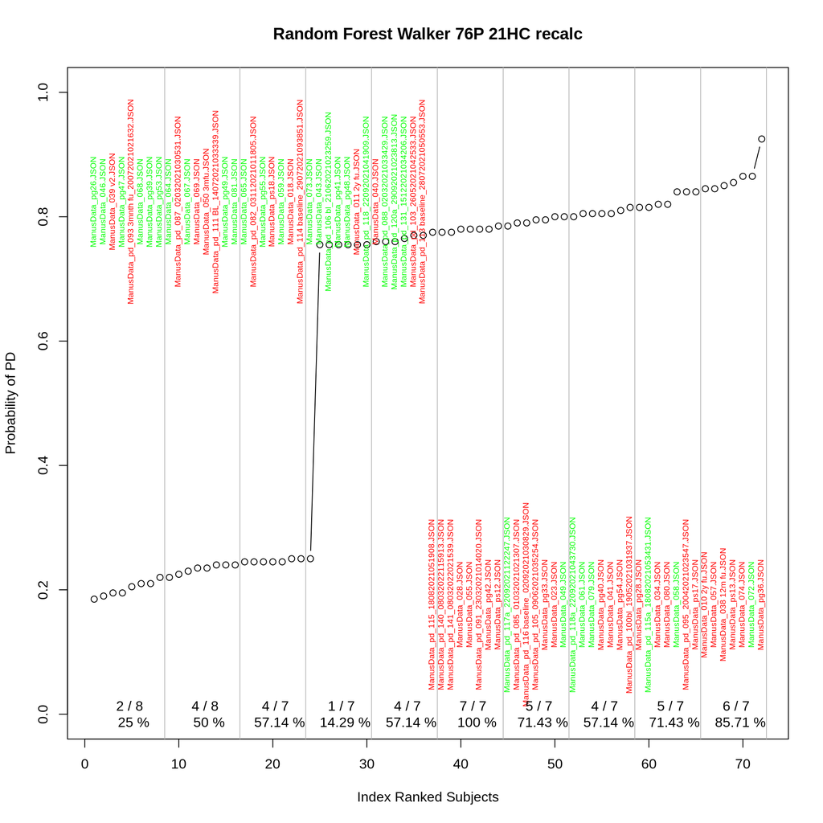

```r
  pred_detail <-  DoClassifyPlots("Random Forest","RanFor")
```

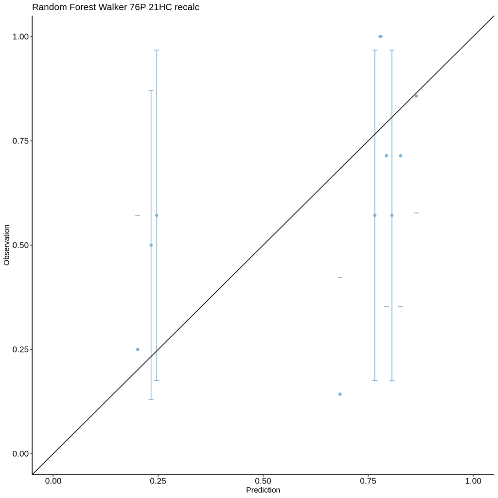

```r
  print(pred_detail$calib$calibration_plot)
```

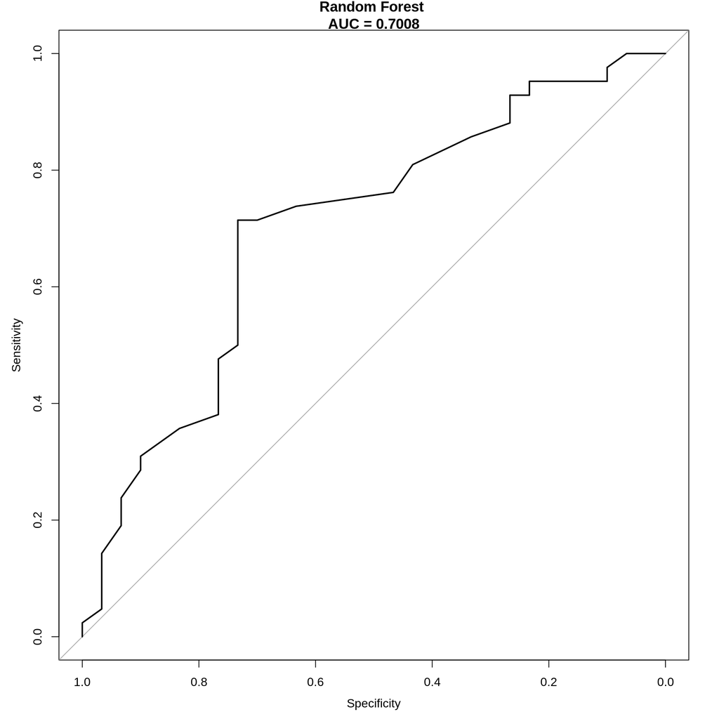

```r
  plot(pred_detail$roc,main=paste(pred_detail$desc,"\nAUC =",round(auc(pred_detail$roc),digits=4)))
```

```r
  print(pred_detail$roc)
```

```
Call:
roc.default(controls = retVal[!isControl, "probPD"], cases = retVal[isControl,     "probPD"], quiet = TRUE)

Data: 30 controls < 42 cases.
Area under the curve: 0.7008
```

```r
  print(kable(pred_detail$calib$data_summary,row.names=FALSE) %>% kable_styling())
```

| decile | obsRate | obsRate_SE | obsNo | predRate | obsRate_UCL | obsRate_LCL |
| --- | --- | --- | --- | --- | --- | --- |
| 1 | 0.2500000 | 0.1636634 | 8 | 0.2012500 | 0.5707803 | -0.0707803 |
| 2 | 0.5000000 | 0.1889822 | 8 | 0.2331250 | 0.8704052 | 0.1295948 |
| 3 | 0.5714286 | 0.2020305 | 7 | 0.2464286 | 0.9674084 | 0.1754488 |
| 4 | 0.1428571 | 0.1428571 | 7 | 0.6828571 | 0.4228571 | -0.1371429 |
| 5 | 0.5714286 | 0.2020305 | 7 | 0.7657143 | 0.9674084 | 0.1754488 |
| 6 | 1.0000000 | 0.0000000 | 7 | 0.7792857 | 1.0000000 | 1.0000000 |
| 7 | 0.7142857 | 0.1844278 | 7 | 0.7935714 | 1.0757642 | 0.3528073 |
| 8 | 0.5714286 | 0.2020305 | 7 | 0.8064286 | 0.9674084 | 0.1754488 |
| 9 | 0.7142857 | 0.1844278 | 7 | 0.8271429 | 1.0757642 | 0.3528073 |
| 10 | 0.8571429 | 0.1428571 | 7 | 0.8642857 | 1.1371429 | 0.5771429 |

```r
  print(kable(SensSpecTableFromROC(pred_detail$roc),col.names=c("threshold","sensitivities","specificities"),row.names=FALSE) %>% kable_styling())
```

| threshold | sensitivities | specificities |
| --- | --- | --- |
| 0.1925 | 100.00 | 6.67 |
| 0.2000 | 97.62 | 10.00 |
| 0.2225 | 95.24 | 23.33 |
| 0.2325 | 92.86 | 26.67 |
| 0.2425 | 85.71 | 33.33 |
| 0.2475 | 80.95 | 43.33 |
| 0.5025 | 76.19 | 46.67 |
| 0.7575 | 73.81 | 63.33 |
| 0.7675 | 71.43 | 73.33 |
| 0.7875 | 47.62 | 76.67 |
| 0.8025 | 35.71 | 83.33 |
| 0.8075 | 30.95 | 90.00 |
| 0.8175 | 23.81 | 93.33 |
| 0.8425 | 14.29 | 96.67 |
| 0.8950 | 2.38 | 100.00 |

### 2.3 BenchMark May 22 (logistic regression, currently Live)

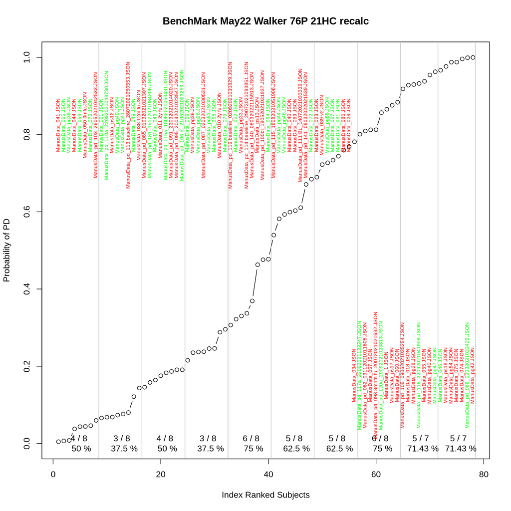

```r
  pred_detail <-  DoClassifyPlots("BenchMark May22","BM_May22")
```

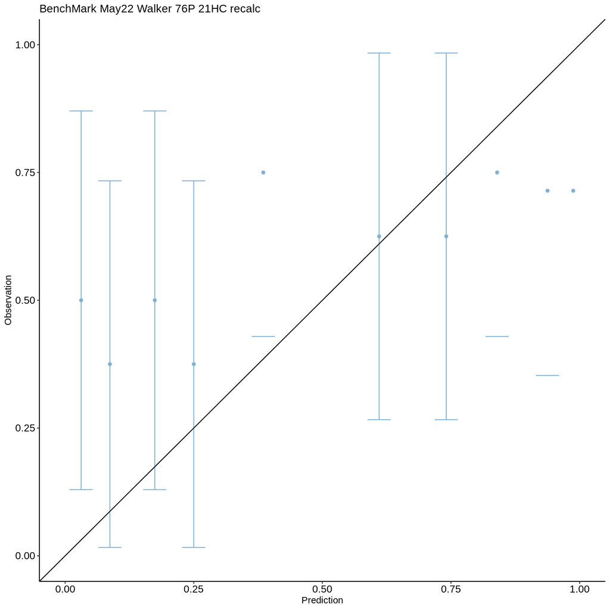

```r
  print(pred_detail$calib$calibration_plot)
```

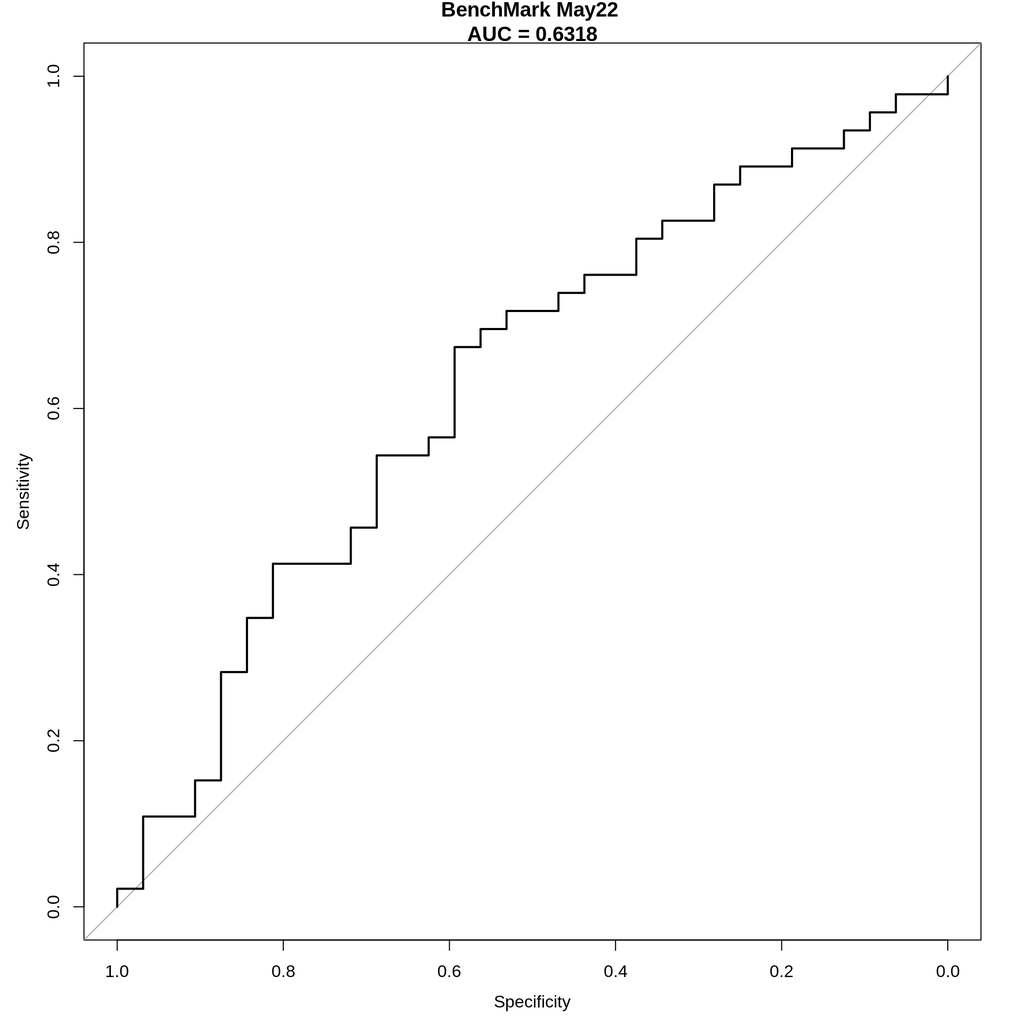

```r
  plot(pred_detail$roc,main=paste(pred_detail$desc,"\nAUC =",round(auc(pred_detail$roc),digits=4)))
```

```r
  print(pred_detail$roc)
```

```
Call:
roc.default(controls = retVal[!isControl, "probPD"], cases = retVal[isControl,     "probPD"], quiet = TRUE)

Data: 32 controls < 46 cases.
Area under the curve: 0.6318
```

```r
  print(kable(pred_detail$calib$data_summary,row.names=FALSE) %>% kable_styling())
```

| decile | obsRate | obsRate_SE | obsNo | predRate | obsRate_UCL | obsRate_LCL |
| --- | --- | --- | --- | --- | --- | --- |
| 1 | 0.5000000 | 0.1889822 | 8 | 0.0311573 | 0.8704052 | 0.1295948 |
| 2 | 0.3750000 | 0.1829813 | 8 | 0.0869856 | 0.7336433 | 0.0163567 |
| 3 | 0.5000000 | 0.1889822 | 8 | 0.1742195 | 0.8704052 | 0.1295948 |
| 4 | 0.3750000 | 0.1829813 | 8 | 0.2500188 | 0.7336433 | 0.0163567 |
| 5 | 0.7500000 | 0.1636634 | 8 | 0.3850971 | 1.0707803 | 0.4292197 |
| 6 | 0.6250000 | 0.1829813 | 8 | 0.6102918 | 0.9836433 | 0.2663567 |
| 7 | 0.6250000 | 0.1829813 | 8 | 0.7407607 | 0.9836433 | 0.2663567 |
| 8 | 0.7500000 | 0.1636634 | 8 | 0.8396008 | 1.0707803 | 0.4292197 |
| 9 | 0.7142857 | 0.1844278 | 7 | 0.9375859 | 1.0757642 | 0.3528073 |
| 10 | 0.7142857 | 0.1844278 | 7 | 0.9875586 | 1.0757642 | 0.3528073 |

```r
  print(kable(SensSpecTableFromROC(pred_detail$roc),col.names=c("threshold","sensitivities","specificities"),row.names=FALSE) %>% kable_styling())
```

| threshold | sensitivities | specificities |
| --- | --- | --- |
| -Inf | 100.00 | 0.00 |
| 0.0226934 | 97.83 | 6.25 |
| 0.0436418 | 95.65 | 9.38 |
| 0.0528590 | 93.48 | 12.50 |
| 0.0680408 | 91.30 | 18.75 |
| 0.0781037 | 89.13 | 25.00 |
| 0.1322627 | 86.96 | 28.12 |
| 0.1697350 | 82.61 | 34.38 |
| 0.1846468 | 80.43 | 37.50 |
| 0.2250916 | 76.09 | 43.75 |
| 0.2371972 | 73.91 | 46.88 |
| 0.2671178 | 71.74 | 53.12 |
| 0.3010890 | 69.57 | 56.25 |
| 0.3260641 | 67.39 | 59.38 |
| 0.5084207 | 56.52 | 62.50 |
| 0.5960933 | 54.35 | 68.75 |
| 0.6869637 | 45.65 | 71.88 |
| 0.7517427 | 41.30 | 81.25 |
| 0.8051423 | 34.78 | 84.38 |
| 0.8611827 | 28.26 | 87.50 |
| 0.9350706 | 15.22 | 90.62 |
| 0.9715495 | 10.87 | 96.88 |
| 0.9993852 | 2.17 | 100.00 |

### 2.4 BenchMark Sep 22 (New classifier, PD part of cascade, Medispa)

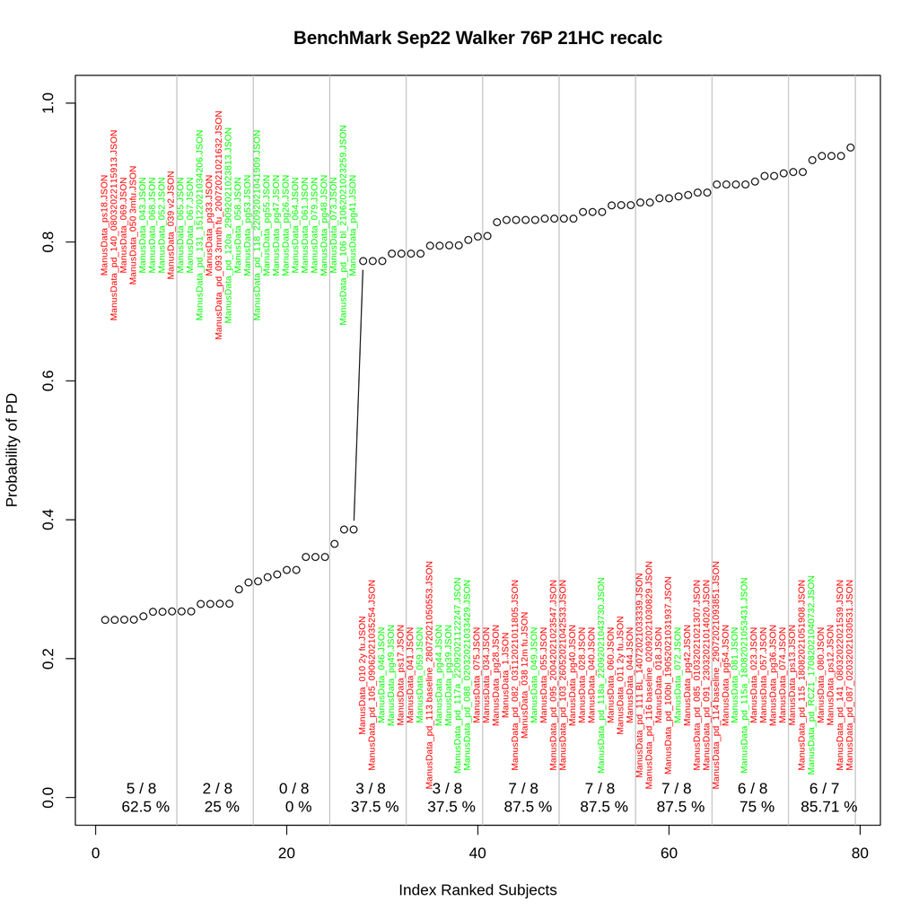

```r
  pred_detail <-  DoClassifyPlots("BenchMark Sep22","BM_PD_Sep22")
```

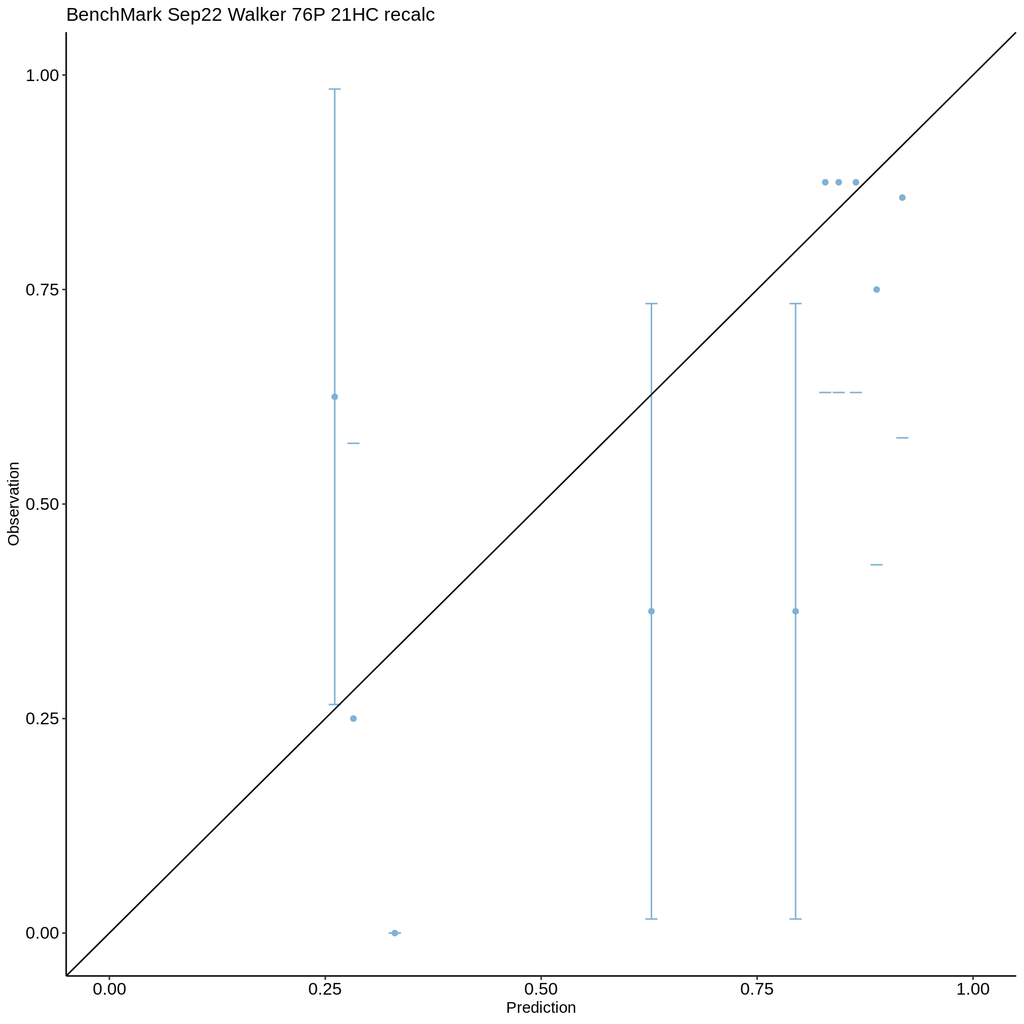

```r
  print(pred_detail$calib$calibration_plot)
```

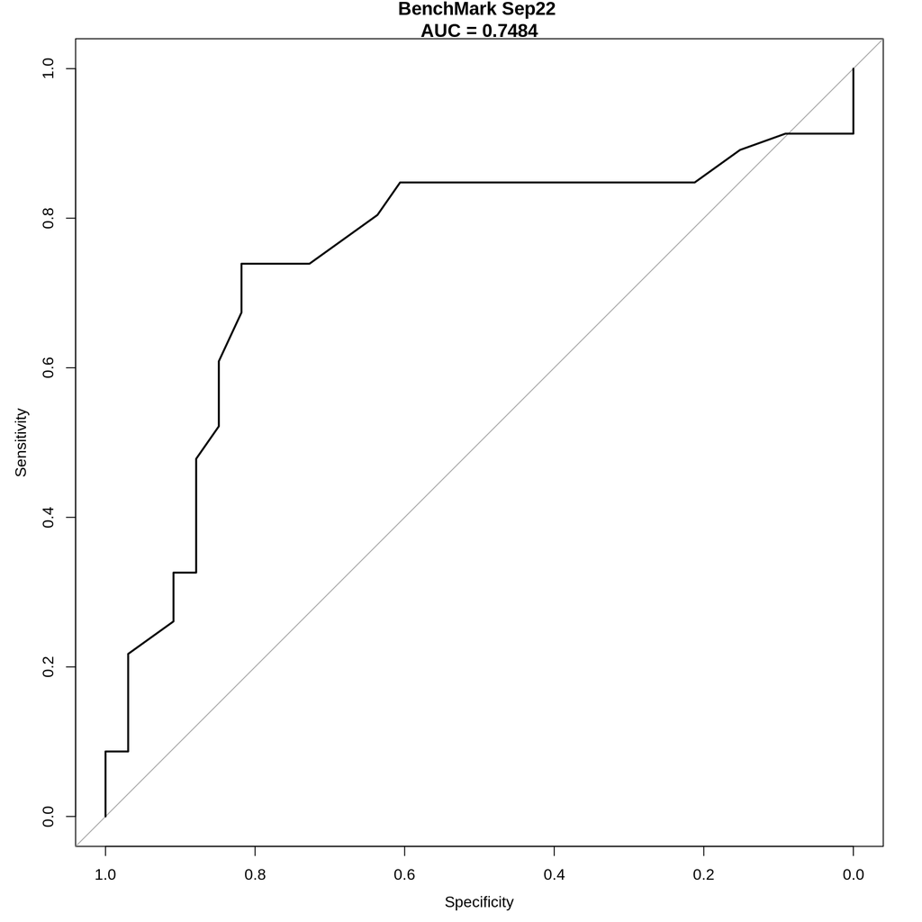

```r
  plot(pred_detail$roc,main=paste(pred_detail$desc,"\nAUC =",round(auc(pred_detail$roc),digits=4)))
```

```r
  print(pred_detail$roc)
```

```
Call:
roc.default(controls = retVal[!isControl, "probPD"], cases = retVal[isControl,     "probPD"], quiet = TRUE)

Data: 33 controls < 46 cases.
Area under the curve: 0.7484
```

```r
  print(kable(pred_detail$calib$data_summary,row.names=FALSE) %>% kable_styling())
```

| decile | obsRate | obsRate_SE | obsNo | predRate | obsRate_UCL | obsRate_LCL |
| --- | --- | --- | --- | --- | --- | --- |
| 1 | 0.6250000 | 0.1829813 | 8 | 0.2609342 | 0.9836433 | 0.2663567 |
| 2 | 0.2500000 | 0.1636634 | 8 | 0.2826068 | 0.5707803 | -0.0707803 |
| 3 | 0.0000000 | 0.0000000 | 8 | 0.3305506 | 0.0000000 | 0.0000000 |
| 4 | 0.3750000 | 0.1829813 | 8 | 0.6276417 | 0.7336433 | 0.0163567 |
| 5 | 0.3750000 | 0.1829813 | 8 | 0.7945827 | 0.7336433 | 0.0163567 |
| 6 | 0.8750000 | 0.1250000 | 8 | 0.8289384 | 1.1200000 | 0.6300000 |
| 7 | 0.8750000 | 0.1250000 | 8 | 0.8444826 | 1.1200000 | 0.6300000 |
| 8 | 0.8750000 | 0.1250000 | 8 | 0.8644256 | 1.1200000 | 0.6300000 |
| 9 | 0.7500000 | 0.1636634 | 8 | 0.8884323 | 1.0707803 | 0.4292197 |
| 10 | 0.8571429 | 0.1428571 | 7 | 0.9181528 | 1.1371429 | 0.5771429 |

```r
  print(kable(SensSpecTableFromROC(pred_detail$roc),col.names=c("threshold","sensitivities","specificities"),row.names=FALSE) %>% kable_styling())
```

| threshold | sensitivities | specificities |
| --- | --- | --- |
| -Inf | 100.00 | 0.00 |
| 0.2677061 | 91.30 | 9.09 |
| 0.2733436 | 89.13 | 15.15 |
| 0.2788638 | 86.96 | 18.18 |
| 0.5792402 | 84.78 | 60.61 |
| 0.7778824 | 80.43 | 63.64 |
| 0.7889161 | 76.09 | 69.70 |
| 0.8053587 | 73.91 | 81.82 |
| 0.8326904 | 60.87 | 84.85 |
| 0.8479572 | 47.83 | 87.88 |
| 0.8666431 | 32.61 | 90.91 |
| 0.8849211 | 21.74 | 96.97 |
| 0.9208701 | 8.70 | 100.00 |